# code003

```python
#Importando Numpy
import numpy as np
```

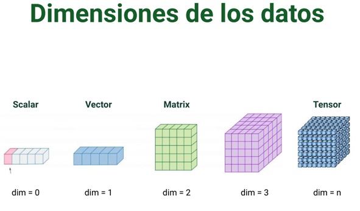

**Las dimensiones en Numpy se ven así.**

- Cuando solo tengo un escalar es una dimensión 0
- Cuando tengo una lista es una dimensión 1
- Cuando tengo una matriz es una dimensión 2
- Cuando tengo un tensor es a partir de una dimensión 3

**Como se puede observar este es un ejemplo en 2D o matriz**

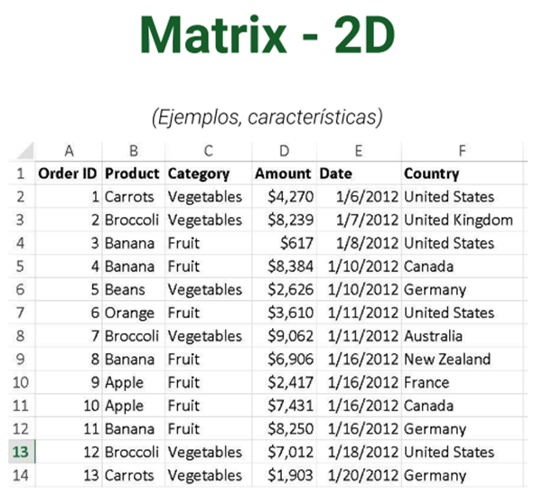

Aquí las dimensiones están dadas por las filas y columnas

**Este es un ejemplo de una aplicación en 3D**

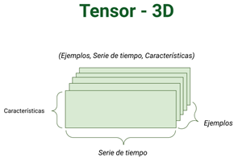

**Finalmente tenemos el 4D que podría ser imagen**

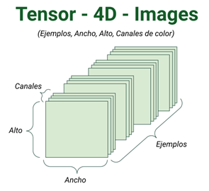

```python
#Dimensiones en Numpy
escalar = np.array(42)
print(f'Escalar = {escalar}\t\tNúmero de dimensiones = {escalar.ndim}')

vector = np.array([1, 2, 3, 4, 5])
print(f'Vector = {vector}\tNúmero de dimensiones = {vector.ndim}')

matriz = np.array([[1,2,3],[4,5,6],[7,8,9]])
print(f'Matriz = \n{matriz}\t\tNúmero de dimensiones = {matriz.ndim}')

tensor = np.array([[ [1,2,2],[3,4,3],[5,6,8] ],[[5,6,2],[6,7,8],[8,9,10]]])
print(f'Tensor = \n{tensor}\t\tNúmero de dimensiones = {tensor.ndim}')
```

```
Escalar = 42		Número de dimensiones = 0
Vector = [1 2 3 4 5]	Número de dimensiones = 1
Matriz =
[[1 2 3]
 [4 5 6]
 [7 8 9]]		Número de dimensiones = 2
Tensor =
[[[ 1  2  2]
  [ 3  4  3]
  [ 5  6  8]]

 [[ 5  6  2]
  [ 6  7  8]
  [ 8  9 10]]]		Número de dimensiones = 3
```

**¿Pero que pasa si yo quiero agregar o eliminar dimensiones?**

```python
#Definiendo un vector con un número de dimensiones
vector = np.array([1,2,3],ndmin=5)
print(f'Vector = {vector}\nDimensiones = {vector.ndim}')
```

```
Vector = [[[[[1 2 3]]]]]
Dimensiones = 5
```

```python
#Expandiendo una dimension en sus ejes
#axis = 0 es filas  Axis = 1 son columnas
vector2 = np.expand_dims(np.array([1,2,3]),axis=0)
print(f'np.array([1,2,3]) = {np.array([1,2,3])}\nDimensiones = {np.array([1,2,3]).ndim}\n')
print(f'np.expand_dims(np.array([1,2,3]),axis=0) = {vector2}\nDimensiones = {vector2.ndim}')
```

```
np.array([1,2,3]) = [1 2 3]
Dimensiones = 1

np.expand_dims(np.array([1,2,3]),axis=0) = [[1 2 3]]
Dimensiones = 2
```

Esto se puede hacer tanto en el axis 0, como en el axis 1

```python
#Eliminando dimensiones
vector = np.array([1,2,3],ndmin=5)
print(f'Vector = {vector}\nDimensiones = {vector.ndim}\n')

vector3 = np.squeeze(vector)
print('Vamos a eliminar dimensiones al vector y guardarlo en vector 3')
print(f'Vector 3 = {vector3}\nDimensiones = {vector3.ndim}\n')
```

```
Vector = [[[[[1 2 3]]]]]
Dimensiones = 5

Vamos a eliminar dimensiones al vector y guardarlo en vector 3
Vector 3 = [1 2 3]
Dimensiones = 1
```

El método *'squeeze()'* hace que el vector se comprima hasta el número de dimensiones que no se están usando

Recordatorio:

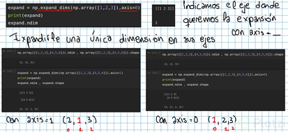

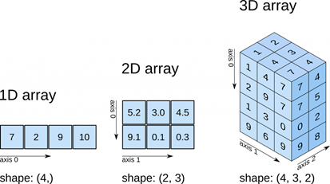

```python
#Declaremos el ejemplo anterior para ver que hace la función shape
#Aquí se puede ver que este array tiene 4 elementos
array1 = np.array([7,2,9,10])
print(f'Array 1 = {array1}\t\tShape = {array1.shape}\n')
#Por ello shape arrojará 4 en la primera dimension

array2 = np.array([ [5.2,3.0,4.5],[9.1,0.1,0.3] ])
print(f'Array 2 = \n{array2}\t\t\tShape = {array2.shape}\n')

array3 = np.array([ [ [1,2],[4,3],[7,4] ], [ [2,5],[9,10],[7,5] ], [ [1,8],[3,7],[0,2] ], [ [9,3],[6,5],[9,8] ] ])
print(f'Array 3 = \n{array3}\t\t\tShape = {array3.shape}\n')
```

```
Array 1 = [ 7  2  9 10]		Shape = (4,)

Array 2 =
[[5.2 3.  4.5]
 [9.1 0.1 0.3]]			Shape = (2, 3)

Array 3 =
[[[ 1  2]
  [ 4  3]
  [ 7  4]]

 [[ 2  5]
  [ 9 10]
  [ 7  5]]

 [[ 1  8]
  [ 3  7]
  [ 0  2]]

 [[ 9  3]
  [ 6  5]
  [ 9  8]]]			Shape = (4, 3, 2)
```

**Reto:**

*Define un tensor con almenos 5 dimensiones e intenta sumar una dimensión en cualquiera de sus ejes o intenta eliminar las dimensiones que no están importando en el objecto que definiste*

```python
#Voy a tomar como referencia la variable array 1; realizar el expand & squeeze

#Proceso de expand a array1
print(f'Array 1 = {array1}\t\tShape = {array1.shape}\n')
print('Expandiendo en dim 1 (filas) => axis = 0')
array1_2 = np.expand_dims(array1,axis=0)
print(f'Array 1v2 = {array1_2}\t\tShape = {array1_2.shape}\n')

#Aplicando squeeze Array 1v2
print('Aplicando squeeze a array 1v2')
array1_2 = np.squeeze(array1_2)
print(f'Array 1v3 = {array1_2}\t\tShape = {array1_2.shape}\n')

#Proceso de expand a array1
print('Expandiendo en dim 2 (columnas) => axis = 1')
array1_2 = np.expand_dims(array1,axis=1)
print(f'Array 1v2 = \n{array1_2}\t\tShape = {array1_2.shape}\n')

#Aplicando squeeze a Array 1v2
print('Aplicando squeeze a array 1v2')
array1_2 = np.squeeze(array1_2)
print(f'Array 1v3 = {array1_2}\t\tShape = {array1_2.shape}\n')
```

```
Array 1 = [ 7  2  9 10]		Shape = (4,)

Expandiendo en dim 1 (filas) => axis = 0
Array 1v2 = [[ 7  2  9 10]]		Shape = (1, 4)

Aplicando squeeze a array 1v2
Array 1v3 = [ 7  2  9 10]		Shape = (4,)

Expandiendo en dim 2 (columnas) => axis = 1
Array 1v2 =
[[ 7]
 [ 2]
 [ 9]
 [10]]		Shape = (4, 1)

Aplicando squeeze a array 1v2
Array 1v3 = [ 7  2  9 10]		Shape = (4,)
```

```python
#Voy a tomar como referencia la variable array 2; realizar expand & squeeze

#Imprimiendo el valor de array 2
print(f'Array 1 = \n{array2}\t\tShape = {array2.shape}\n')

#Proceso de expand a array2
print('Expandiendo en dim 1 (filas) => axis = 0')
array2_2 = np.expand_dims(array2,axis=0)
print(f'Array 1v2 = \n{array2_2}\tShape = {array2_2.shape}\n')

#Aplicando squeeze Array 2v2
print('Aplicando squeeze a array 2v2')
array2_2 = np.squeeze(array2_2)
print(f'Array 1v3 = \n{array2_2}\t\tShape = {array2_2.shape}\n')

#Proceso de expand a array2
print('Expandiendo en dim 2 (columnas) => axis = 1')
array2_2 = np.expand_dims(array2,axis=1)
print(f'Array 1v2 = \n{array2_2}\tShape = {array2_2.shape}\n')

#Aplicando squeeze Array 2v2
print('Aplicando squeeze a array 2v2')
array2_2 = np.squeeze(array2_2)
print(f'Array 1v3 = \n{array2_2}\t\tShape = {array2_2.shape}\n')
```

[output not shown]

```python
#Quiero verificar que no se puede expandir en una dimensión que no existe, en este caso en dim 3, axis = 2

#Proceso de expand a array2
print('Expandiendo en dim 3 => axis = 2')
array2_2 = np.expand_dims(array2,axis=2)
print(f'Array 1v2 = \n{array2_2}\tShape = {array2_2.shape}\n')
```

```
Expandiendo en dim 3 => axis = 2
Array 1v2 =
[[[5.2]
  [3. ]
  [4.5]]

 [[9.1]
  [0.1]
  [0.3]]]	Shape = (2, 3, 1)
```

```python
#Si se pudó pero ahora comprobemos que no podemos brinca de dim 3 a dim 5; axis = 4
#Proceso de expand a array2
print('Expandiendo en dim 5 => axis = 4')
array2_2 = np.expand_dims(array2,axis=4)
print(f'Array 1v2 = \n{array2_2}\tShape = {array2_2.shape}\n')
```

```
Expandiendo en dim 5 => axis = 4
```

[output not shown]

**Como podemos comprobar nos manda el siguiente mensaje:**

*AxisError: axis 4 is out of bounds for array of dimension 3*

Esto quiere decir que la dimensión a expandir está fuera del alcance

```python
#Ahora vamos a usar la variable array 3 para crear otra variable con una dimensión minima de 5
#Recordando a la variable array 3
print(f'Array 3 = \n{array3}\t\t\tShape = {array3.shape}')

#Creamos una nueva variable con una dimensión minima de 5
array4 = np.array(array3,ndmin=5)
print(f'Array 4 = \n{array4}\t\t\tShape = {array4.shape}')
```

```
Array 3 =
[[[ 1  2]
  [ 4  3]
  [ 7  4]]

 [[ 2  5]
  [ 9 10]
  [ 7  5]]

 [[ 1  8]
  [ 3  7]
  [ 0  2]]

 [[ 9  3]
  [ 6  5]
  [ 9  8]]]			Shape = (4, 3, 2)
Array 4 =
[[[[[ 1  2]
    [ 4  3]
    [ 7  4]]

   [[ 2  5]
    [ 9 10]
    [ 7  5]]

   [[ 1  8]
    [ 3  7]
    [ 0  2]]

   [[ 9  3]
    [ 6  5]
    [ 9  8]]]]]			Shape = (1, 1, 4, 3, 2)
```